# 21-01 주제분석 1주차 패키지

- 주제분석 1주차 분석 툴은 Python/R 둘 다 가능합니다.
  - 1-3주차 패키지 문제의 조건 및 힌트는 Python을 기준으로 하지만, R을 사용해도 무방합니다.
  - 다만 2/3주차의 머신러닝/딥러닝 모듈을 편하게 사용하기 위해서는 Python이 더 편할겁니다.
- 제출형식은 pdf/html/doc/ppt 등 발표가 가능하면 괜찮습니다. 하지만 html로 주시면 가장 감사합니다.
- 패키지 과제 발표는 세미나 쉬는시간 이후에 하게 되며, 역시 랜덤으로 5시00분에 발표됩니다.
- 제출기한은 목요일 자정까지이며 지각시 벌금 5000원이 있습니다. 미제출 시 만원입니다.
  - 패키지 2회 무단 미제출 시 퇴출이니 유의해 주세요.

## 0. 들어가기 전에

### 0.1 데이터 소개

주어진 데이터 파일은 '직방'에서 제공한 데이터로, Dacon 4회 컴피티션 '아파트 실거래가 예측'의 데이터입니다. 이 데이터에는 우리가 예측하고자 하는 'Y : 아파트실거래가'와 아파트 거래인, 지역, 전용면적, 공급면적 등의 정보가 포함됩니다. 대회 직후 연습용으로 바뀐 데이터 셋이니 사용해도 문제없습니다!

1,000,000 여 개의 train data와 500,000 여 개의 test data가 주어집니다. 하지만 컴피티션 특성상 대회 후 연습용이더라도 test data에는 Y가 포함되어 있지 않습니다. 따라서 train data를 일부 분리해서 평가하려 합니다. 아파트 거래일 기준으로 2008년부터 2017년까지 데이터가 존재하기 때문에, 상대적으로 가벼운 환경에서 분석을 위해 데이터 셋을 일부 제한해서 모델을 만들 계획입니다.

### 0.2 1주차 패키지 목표

클린업 패키지는 R을 기반으로 만들었지만, 주제분석 패키지는 Python을 기반으로 만들었습니다. 따라서 기본적으로 파이썬에서 데이터프레임을 다루는 Pandas를 익숙하게 하고, matplotlib을 통한 시각화를 다루려 합니다.

데이터 탐색과 시각화 후, 여기서 얻은 인사이트를 바탕으로 전처리를 시행하는 과정들을 거칠 예정입니다. 물론 우리가 데이터 분석을 하면 예상되는 결과와 실제 결과가 다를 경우도 많고, 이번 패키지도 그렇습니다... 하지만 분석의 흐름과 논리를 조금은 더 익숙하게 만들어 드리고 싶네요...!

더불어서 이미 클린업을 통해 여러 이론적인 내용들을 다뤘기 때문에, 조금 다양한 방식의 전처리들을 다루려 합니다. 시계열 주기성을 고려한 인코딩, 텍스트 데이터 전처리, 범주형 자료 인코딩 등이 포함될 예정입니다. 어려울 수 있지만 최대한 힌트와 함께 구성될 예정이니 따라와 주세요!

### 0.3 본격적인 시작 전에

다음의 코드를 시행해주세요

```python
import numpy as np
import pandas as pd
```

- 파이썬은 'import 라이브러리 as 축약어' 형태로 불러옵니다.
- pandas는 데이터프레임을 다루는 라이브러리
- numpy는 숫자와 연산을 다루는 라이브러리
- 추가적으로 다른 라이브러리들이 필요하지만, 추후에 불러오겠습니다.

## 1. 데이터 전처리

파이썬으로 기본적인 데이터 탐색을 시작합니다.

### 1.1 데이터 불러오기

- pandas의 `read.csv` 함수를 이용해 주어진 데이터를 불러오세요.

### 1.2 데이터 확인

- 데이터가 row와 column 수를 확인하세요.
- 어떤식으로 생겼는지 `head`, `info` 등을 활용해 확인하세요.
- 결측값은 없는지 확인하세요. numpy의 `isnull`을 이용해 확인이 가능합니다.

### 1.3 불필요한 행 삭제 (reset index)

- 현재는 city 컬럼에 서울과 부산이 동시에 있습니다. 서울인 행만 남기세요.
- 파이썬의 데이터프레임은 일부 행을 삭제해도 인덱스가 수정되지 않습니다. `reset_index`를 이용해 인덱스를 재정렬하세요.

### 1.4 변수 이름 바꾸기

- `transaction_real_price`는 너무 깁니다.
- 이를 `price`로 바꿔줍시다

### 1.5 불필요한 변수 삭제

- `transaction_id` 변수는 인덱스이니 삭제합니다.
- `apartment_id` 변수는 다른 변수와 겹치니 삭제합니다.
- `jibun` 변수는 너무 지엽적이고, 유의미하지 않을 것으로 예상되니 삭제합니다.
- `city`는 지금 서울 하나뿐이니 삭제합시다.
- 변수들을 삭제하고 데이터프레임의 차원을 재확인 해주세요.

### 1.6 연/월 뽑기

- 현재는 연도와 월이 동시에 기재되어 있습니다. 이를 분리해줍시다.
- 해당 컬럼을 삭제하지는 말고, 연도+월/연도/월 이렇게 총 세가지 컬럼이 남아 있으면 됩니다.
- 해당 컬럼의 이름은 `transaction_year`, `transaction_month`로 해주세요.

### 1.7 필요 연도 뽑기

- 너무 오래전의 데이터는 현재의 가격에 유의미한 영향을 미치지 않을 것 같습니다.
- 더불어서 현재 데이터가 너무 많습니다. 조금이라도 줄이기 위해 연도를 제한합시다.
- 2012년도부터의 데이터만 사용하도록 뽑습니다. 이후 인덱스도 재정렬해줍시다.

## 2. 데이터 시각화

해야하니까 하는 EDA를 넘어서, 파생변수를 생성하는데에 있어서 유의미한 인사이트를 얻기 위해 노력해봅시다.

일단 그려보기도 하지만, 분석과 관계된 가설을 파악하기 위해 시각화를 진행하는 경우가 많습니다.

- 만약 `matplotlib`이 너무 불편하면 python의 ggplot2인 `plotline`을 사용해도 괜찮습니다.
  - 다만 어렵지 않은 시각화 위주로 가려하니, 파이썬의 방식에 익숙해져봅시다.
- `matplotlib`과 더불어 `seaborn`을 이용해도 괜찮습니다. 색과 같이 세부적인 것은 똑같지 않아도 됩니다.
- 오늘의 시각화는 '예쁘게 하기'보다 '일단 그리기'에 초점을 맞췄습니다.
  - 예시에서는 `matplotlib`과 `seaborn`을 왔다갔다 하니까, 큰틀에서만 똑같게 그려주시면 됩니다.
- 추가적으로 예쁘게 그리시면 우수 답안으로 선정될 가능성이 높아집니다.
- 모든 플랏에는 간단하게나마 해석을 덧붙여 주세요!

먼저 다음의 코드를 실행합니다.

```python
import matplotlib.pyplot as plt
import seaborn as sns
```

### 2.1 거래가격 분포 확인

첫번째 matplotlib/seaborn 시각화인만큼, 코드는 주어져 있습니다. 주석까지 달아둘게요. 조금 수정해볼까요?

- 거래가격 변수의 분포를 boxplot과 histogram을 이용해 확인합니다.
- 기본적인 플랏은 있는데, 각각 x축 이름을 'Price'로 추가하세요.
- 박스플랏 왼쪽의 혼자 있는 1이 거슬리니 지워보세요! 나중에 다시 와서 천천히 지워봐도 됩니다.
- 결과를 간단히 해석해주세요!

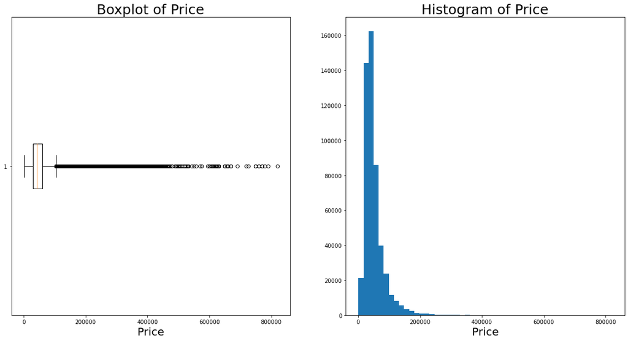

```python
firstplot = plt.figure(figsize=(20,10)) # (20, 10)  사이즈의 firstplot이란 plot을 생성할거임
axes1 = firstplot.add_subplot(1, 2, 1) # 플랏을 분할할건데, 1행 2열로 분할할거고, 이건 그중 첫번째 플랏임
axes2 = firstplot.add_subplot(1, 2, 2) # 이건 그중에 두번째 플랏임

# axes1.boxplot # 첫번째 플랏에는 boxplot을 그릴건데, 가로로 눕힐거임
# axes1.set_title # 플랏 제목도 달고, 폰트 사이즈도 지정줄거임

# axes2.hist # 두번째 플랏은 히스토그램 그릴거임
# axes2.set_title
```

```
[Text(0.5, 0, 'Price'), Text(0.5, 1.0, 'Histogram of Price')]
```

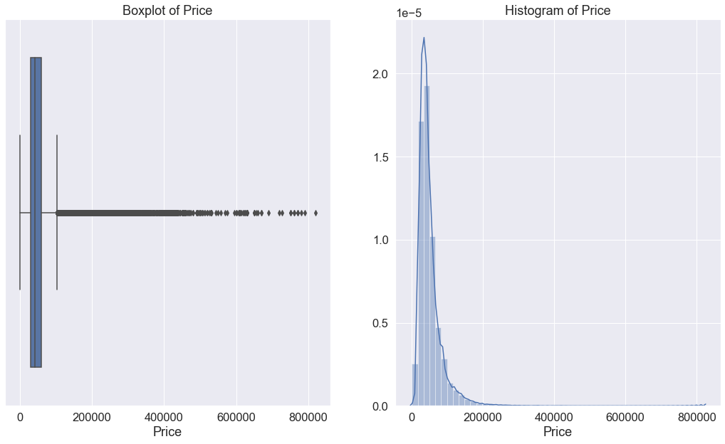

```python
# sns.set(font_scale = ) # 폰트사이즈를 전체적으로 키워준다
fig, axs = plt.subplots(ncols = 2, figsize = (18, 10)) #서브플랏을 1행 2열로 분할하고
# sns.boxplot 박스플랏
# sns.distplot 히스토그램
```

### 2.2 거래연도 분포 확인 / 거래연도별 가격 분포 확인

- 왼쪽에는 거래연도별 거래 횟수의 분포를, 오른쪽에는 거래연도별 거래 가격의 분포를 그려주세요.
- 더불어서 제목, y축 label을 쓰세요.
- 플랏을 해석해주세요.

```
[Text(0, 0.5, 'Price')]
```

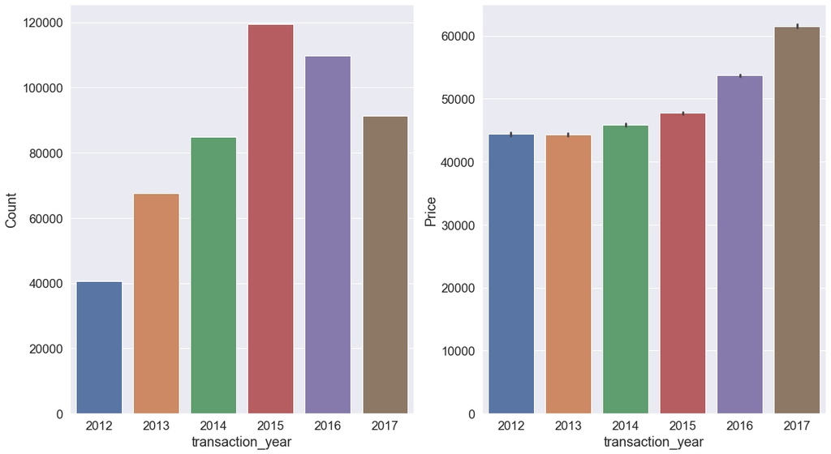

### 2.3 층 분포 확인 / 층별 가격 분포 확인

- 왼쪽에는 층별 거래횟수의 분포를, 오른쪽에는 층별 평균거래가격의 분포를 그려주세요.
- 오른쪽 barplot의 error바는 없애서 표현해주세요
- x축은 없애주세요
- '고층일수록 비싸지 않을까?' 라는 가설을 확인하기 위함입니다.
- 결과를 해석해주세요

```
[Text(0, 0.5, 'Price'), []]
```

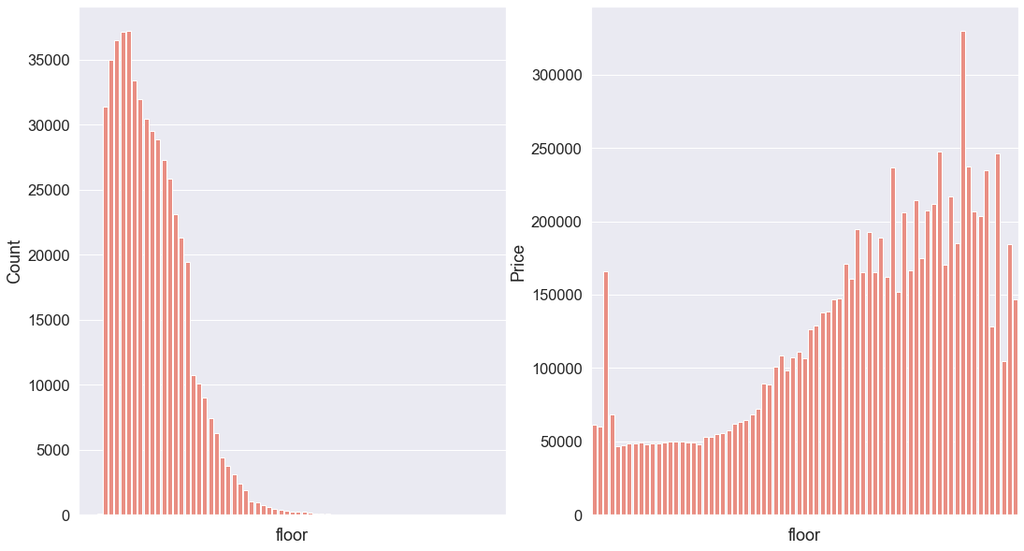

### 2.4 완공연도 분포 확인 / 완공연도별 가격 분포 확인

- 왼쪽에는 완공연도별 거래횟수의 분포를, 오른쪽에는 완공연도별 평균거래가격의 분포를 그려주세요.
- x축은 없애주세요. 오른쪽일수록 최근입니다.
- '최근의 아파트들이 더 비싸지 않을까?'라는 가설을 확인하고 싶습니다.
- 결과를 해석해주세요.

```
[Text(0, 0.5, 'Price'), []]
```

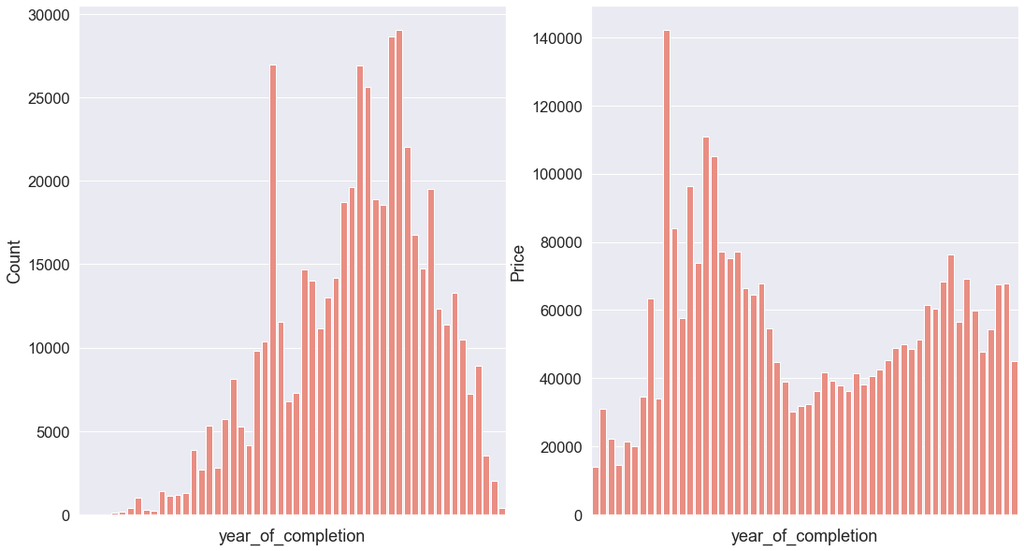

## 3. 파생변수 생성

### 3.1 아파트 연차 변수 생성

- 아파트 연차가 오래될수록 거래가격이 낮지 않을까?
- 이를 반영하기 위해 아파트 연차 변수 `until_trans`를 생성합시다.
- 그리고 이를 시각화해봅시다.
- 그리고 해석해주세요
- 단순히 아파트 연차를 넣는 것 이외에 어떤 방식으로 파생변수를 만들 수 있을까요?

```
[Text(0, 0.5, 'Price'), []]
```

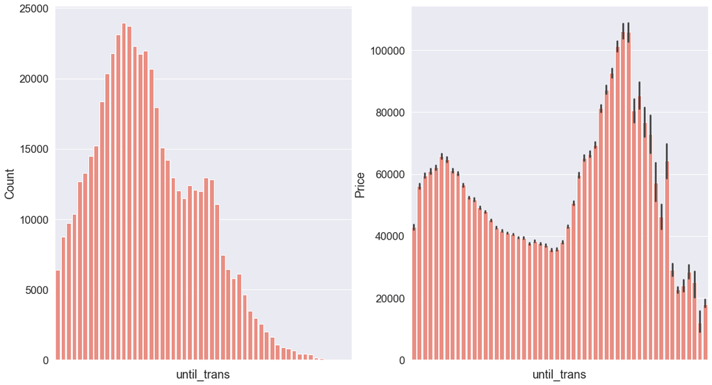

### 3.2 거래 일 변수 변환

- `1~10`은 0으로, `11~20`은 1로, `21~28/21~29/21~30/21~31`은 2로 변환하자.
- `np.where`을 쓰면 편합니다. R의 `ifelse`라고 생각하면 됩니다.

### 3.3 월 변수와 10일 단위 변수 통합

- 10일 단위로 월/일 변수를 통합하는 과정입니다.
- 월과 일을 한번에 다룰 수 있도록 파생변수를 만들어주세요
- 변수 이름은 `transaction_month_date`로 해주세요.
- 다음과 같은 결과가 나오면 됩니다.

```python
data[['transaction_month_date', 'transaction_month', 'transaction_date']]
```

|  | transaction_month_date | transaction_month | transaction_date |
| --- | --- | --- | --- |
| 0 | 3 | 01 | 0 |
| 1 | 4 | 01 | 1 |
| 2 | 4 | 01 | 1 |
| 3 | 3 | 01 | 0 |
| 4 | 5 | 01 | 2 |
| ... | ... | ... | ... |
| 513523 | 34 | 11 | 1 |
| 513524 | 35 | 11 | 2 |
| 513525 | 35 | 11 | 2 |
| 513526 | 35 | 11 | 2 |
| 513527 | 35 | 11 | 2 |

513528 rows × 3 columns

### 3.4 연도별 주기성을 위한 파생변수 생성 (삼각변환)

- https://ianlondon.github.io/blog/encoding-cyclical-features-24hour-time/
- 다음의 자료를 참고해서 3.3에서 생성한 변수에 대해 삼각변환을 시행해주세요!
- 변수명은 `sin_date`, `cos_date`로 지정해주세요.
- `year_of_completion`, `transaction_year_month`, `transaction_date`, `transaction_month`, `transaction_month_date` 변수를 제거하세요

```python
import math # 삼각변환 위한 패키지
```

### 3.5 삼각변환을 통한 장점

- 만약 이런식으로 처리하지 않고, 시기별로 dummy(one-hot)을 잡거나, label인코딩을 하면 어떻게 될까요?
- 이런식으로 삼각변환 했을 때의 장점을 말해주세요.
- 다음의 자료를 참고하세요. 직접적으로 관련되기도, 간접적으로 관련되기도 합니다.
  - https://towardsdatascience.com/cyclical-features-encoding-its-about-time-ce23581845ca
  - 꼭 둘다 읽어주세요!
  - https://skyjwoo.tistory.com/entry/positional-encoding%EC%9D%B4%EB%9E%80-%EB%AC%B4%EC%97%87%EC%9D%B8%EA%B0%80
  - 현재 자연어처리에 가장 많이 사용되는 트랜스포머 구조에서 positional encoding에 대한 설명입니다.

## 4. 텍스트 데이터 다루기

보통 이런 정형데이터 분석에서 텍스트 데이터가 끼면 난감합니다. 다만 이런 텍스트들에도 유의미한 정보들이 존재할겁니다.

- 우리는 보통 아파트 이름에 막 영어 들어가고 세련될수록 비쌀 것이라고 예측할 수 있습니다.
- 무궁화아파트보다는 힐스테이트, 롯데캐슬이 더 비쌀 것 같잖아요?
- 이런 정보를 담아낼 수 있도록 과정을 거쳐봅시다.

### 4.1 아파트 이름 한글부분만 뽑기

아파트의 이름만 가져와서, 한글만 남기세요.

- 데이터의 `apt`열을 가져와서 `apt` 변수명에 저장하세요.
- 특수문자/숫자를 모두 제거하세요.
- 앞에 `광화문`과 같은 지역명은 그냥 남기세요.
- 해당 결과를 head를 통해 보여주세요.

### 4.2 아파트 이름 DTM

아파트 이름에 대한 문서단어행렬을 만드세요.

- 사이킷런의 `CountVectorizer`를 이용하세요. 이때 `min_df = 5`로 지정해주세요.

```python
from sklearn.feature_extraction.text import CountVectorizer
```

### 4.3 아파트 이름 tf-idf

아파트 이름에 대한 문서단어행렬을 만드세요.

- 사이킷런의 `TfidfVectorizer`를 이용하세요. 이때 `min_df = 5`로 지정해주세요.

```python
from sklearn.feature_extraction.text import TfidfVectorizer
```

### 4.4 질문

해당 방식으로 만든 행렬을 원래 데이터프레임에 붙여서 분석/모델링을 진행한다고 생각해봅시다.

- 어떤 문제점이 발생할 수 있을까요?
- 해당 어떤 방식으로 개선할 수 있을까요?

### 4.5 질문

신입기수분들은 4.5번에 반드시 답변하지 않아도 괜찮습니다.

만약 해당 아파트 이름을 word2vec으로 임베딩해, 임베딩된 행렬을 원래 데이터프레임에 붙여서 문석 모델링을 진행한다고 합시다.

- 이때 word2vec은 100차원에 임베딩 됩니다. (size=100)
- word2vec은 잘 작동할 수 있을까요?
- 만약에 잘 작동할/작동하지 않을 것 같다면 그 이유를 설명해주세요.
- 2021-01/2020-02 딥러닝 팀 3주차 교안을 참고하는 것도 좋습니다.

## 5. 인코딩

현실적인 이유로 정형데이터 모델링에서는 텍스트를 자연어처리에서의 접근으로 임베딩하는 것보단, 인코딩하는 것이 일반적입니다. 다만 동일하게 원핫으로 하게되면 범주가 많은 경우 힘들 수 있겠죠? 어려움을 직접 마주하고 해결해봅시다.

```python
data = data.drop(columns = ['addr_kr'])
```

### 5.1 원핫 인코딩

- `dong`과 `apt` 변수에 대해 원핫 인코딩을 시행하고, `원래변수명_onehot`로 저장해주세요.
- 조금 오래 걸릴 수 있습니다.
- 만들어진 데이터프레임의 차원을 확인하고, 원핫 인코딩이 이 상황에 적절할지 말해주세요.

### 5.2 레이블(label) 인코딩 - transaction_year

- 원래 데이터에서 `transaction_year`에 대해 label 인코딩을 시행하세요. 그리고 `head()`로 결과를 보여주세요.
- 연도 자체는 하나의 범주로 인식할 수 있으니 인코딩을 시행해줍니다.
- 이런 인코딩이 적절할지 2.2의 시각화를 보고 답변해주세요.

```python
data.head()
```

|  | dong | apt | exclusive_use_area | floor | price | transaction_year | until_trans | sin_date | cos_date |
| --- | --- | --- | --- | --- | --- | --- | --- | --- | --- |
| 0 | 사직동 | 광화문풍림스페이스본(9-0) | 95.88 | 6 | 70000 | 0 | 5 | -1.000000e+00 | -1.836970e-16 |
| 1 | 사직동 | 광화문풍림스페이스본(9-0) | 108.55 | 11 | 100500 | 0 | 5 | -2.449294e-16 | 1.000000e+00 |
| 2 | 사직동 | 광화문풍림스페이스본(9-0) | 94.51 | 1 | 65800 | 0 | 5 | -2.449294e-16 | 1.000000e+00 |
| 3 | 수송동 | 로얄팰리스스위트 | 42.87 | 8 | 30500 | 0 | 8 | -1.000000e+00 | -1.836970e-16 |
| 4 | 수송동 | 로얄팰리스스위트 | 39.67 | 15 | 30500 | 0 | 8 | 1.000000e+00 | 3.061617e-16 |

### 5.3 레이블(label) 인코딩

- `dong`과 `apt` 변수에 대해 레이블 인코딩을 시행하고, `원래변수명_label`로 저장해주세요.
- 그리고 `head()`로 결과를 보여주세요.
- 이런 방식의 인코딩이 적절한지 답변해주세요.

```python
data_label.head()
```

|  | dong | apt | exclusive_use_area | floor | price | transaction_year | until_trans | sin_date | cos_date |
| --- | --- | --- | --- | --- | --- | --- | --- | --- | --- |
| 0 | 130 | 805 | 95.88 | 6 | 70000 | 0 | 5 | -1.000000e+00 | -1.836970e-16 |
| 1 | 130 | 805 | 108.55 | 11 | 100500 | 0 | 5 | -2.449294e-16 | 1.000000e+00 |
| 2 | 130 | 805 | 94.51 | 1 | 65800 | 0 | 5 | -2.449294e-16 | 1.000000e+00 |
| 3 | 164 | 2042 | 42.87 | 8 | 30500 | 0 | 8 | -1.000000e+00 | -1.836970e-16 |
| 4 | 164 | 2042 | 39.67 | 15 | 30500 | 0 | 8 | 1.000000e+00 | 3.061617e-16 |

### 5.3 mean encoding

- `원래변수명_mean`을 만드세요.
- 해당 데이터에 대해 `apt`변수에 대해 mean encoding을 시행하세요. `head()`를 통해 확인하세요.
- 이런 인코딩이 적절할지, 장/단점에 대해 말해주세요.

```python
data.head()
```

|  | dong | apt | exclusive_use_area | floor | price | transaction_year | until_trans | sin_date | cos_date |
| --- | --- | --- | --- | --- | --- | --- | --- | --- | --- |
| 0 | 130 | 91174.766355 | 95.88 | 6 | 70000 | 0 | 5 | -1.000000e+00 | -1.836970e-16 |
| 1 | 130 | 91174.766355 | 108.55 | 11 | 100500 | 0 | 5 | -2.449294e-16 | 1.000000e+00 |
| 2 | 130 | 91174.766355 | 94.51 | 1 | 65800 | 0 | 5 | -2.449294e-16 | 1.000000e+00 |
| 3 | 164 | 36609.649123 | 42.87 | 8 | 30500 | 0 | 8 | -1.000000e+00 | -1.836970e-16 |
| 4 | 164 | 36609.649123 | 39.67 | 15 | 30500 | 0 | 8 | 1.000000e+00 | 3.061617e-16 |

### 5.4 catboost encoding

- 다음 주에 할까요?